# Analisis del IPC de Aceites y los Commodities

Gari jerez

05 February 2025

## 1. Introducción

Los commodities son bienes básicos que se utilizan como insumos en la producción de otros bienes y que pueden ser usados en el comercio o en el sector financiero, como objetos de adquisición (activos subyacentes). Su principal característica y ventaja es que tienen valor, un bajo nivel de procesamiento y utilidad.

Los Commodities se clasifican en 5 grupos:

- Granos: Soja, Trigo, Maiz, Avena y Cebada.
- Softs: Algodón, Jugo de Naranja, Café, Azúcar y Cacao.
- Energías: Petróleo Crudo, Fuel Oil, Gas Natural, Etanol y Nafta.
- Metales: Oro, Plata, Cobre, Platino, Aluminio y Paladio.
- Carnes: Ganado Bovino Vivo, Ganado Porcino Vivo, Manteca y Leche.

Dichos precios son recolectados por el Banco Mundial para la finalidad de medir las perspectivas futuras de los productos. dichos informen contribuyen de forma significativa para medir: el crecimiento de la actividad industrial de las principales economias, condiciones de suministro, tensiones geopolitcas, entre otras.

este pequeño reporte lo que busca es medir si realmente los precios internacionales de los aceites impactan las variedades de los aceites del IPC con cierta intensidad o posible retraso.

## 2. Datos

se utilizo la serie de los precios internacionales de los aceites (commodities) del Banco Mundial y la serie de las variedades de los precios de los aceites del INdice de Precios al Consumidor (IPC) del Banco Central de la Republica Dominicana.

cabe destacar que la informacion de la serie de precios del IPC esta a partir del cambio de base reciente a partir de octubre 2020.

## 3. Tablas

La primera tabla esta compuesta por los precios de los commodities los cuales estan compuestos por los precios de:

Tabla 1.1 Precios de los commodities del 2020 al 2024.

| Fecha | Aceite de Coco | Aceite de Mani | Aceite de Palma | Aceite de Palmiste | Aceite de Soya | Aceite de Colza | Aceite de Girasol |
| --- | --- | --- | --- | --- | --- | --- | --- |
| 2020-10-01 | 1118.3599999999999 | 1877.59 | 819.27 | 805.91 | 914.77 | 927.71 | 981.40243902438999 |
| 2020-11-01 | 1368.95 | 1878.61 | 917.81 | 1073.48 | 973.88 | 1047.78 | 1109.1124661246599 |
| 2020-12-01 | 1464.9645697758499 | 1977.1738914549701 | 1016.37389145497 | 1224.8682051282101 | 1026.1958677686 | 1097.6258446601901 | 1170.02032520325 |
| 2021-01-01 | 1463.07 | 1988.94048883757 | 990.27 | 1368.31 | 1098.67 | 1141.24 | 1276.1178861788601 |
| 2021-02-01 | 1444.5 | 1993.2059724793701 | 1019.86 | 1359.5 | 1123.5 | 1272.1300000000001 | 1362.56775067751 |
| 2021-03-01 | 1540.65 | 2006.0389818224601 | 1030.48 | 1478.59 | 1284.81 | 1321.88 | 1611.1111111111099 |
| 2021-04-01 | 1659.64 | 2020.63680170152 | 1078.05 | 1487.14 | 1386.35 | 1312.33 | 1572.7981029810301 |
| 2021-05-01 | 1715.24 | 2072.0399166727998 | 1136.46 | 1530.5 | 1574.67 | 1531.38 | 1584.58672086721 |
| 2021-06-01 | 1670.68 | 2078.8257589914201 | 1004.42 | 1400.45 | 1518.16 | 1527.59 | 1296.74796747967 |
| 2021-07-01 | 1584.09 | 2092.1928941281099 | 1062.99 | 1274.0899999999999 | 1468.34 | 1410.08 | 1282.0121951219501 |

La siguiente tabla contiene la serie de precios del Grupo Alimentos y bebidas no alcoholicas de la sub clase de los articulos de los aceites del IPC:

Tabla 1.2 IPC aceites.

| Fecha | Aceite y grasas | Aceites | Aceite de soya | Aceite puro de origen vegetal |
| --- | --- | --- | --- | --- |
| 2020-10-01 | 104.893 | 104.857 | 104.85599999999999 | 104.86199999999999 |
| 2020-11-01 | 106.604 | 106.66500000000001 | 106.66200000000001 | 106.71899999999999 |
| 2020-12-01 | 108.428 | 108.533 | 108.56399999999999 | 107.99299999999999 |
| 2021-01-01 | 111.06699999999999 | 111.374 | 111.401 | 110.89700000000001 |
| 2021-02-01 | 114.676 | 115.41500000000001 | 115.495 | 114.01300000000001 |
| 2021-03-01 | 117.07899999999999 | 118.06 | 118.188 | 115.804 |
| 2021-04-01 | 118.869 | 120.017 | 120.18 | 117.136 |
| 2021-05-01 | 125.238 | 127.157 | 127.639 | 118.625 |
| 2021-06-01 | 134.37 | 137.22300000000001 | 138.154 | 120.73399999999999 |
| 2021-07-01 | 139.476 | 142.768 | 143.94200000000001 | 121.96599999999999 |

la siguiente tabla muestra la construccion de los indices de cada uno de las dos bases de datos para realizar dichos analisis:

```
## # A tibble: 10 × 18
##    Año   Mes      Aceite_y_grasas Aceites Aceite_de_soya Aceite_puro_de_origen…¹
##    <chr> <chr>              <dbl>   <dbl>          <dbl>                   <dbl>
##  1 2020  October             105.    105.           105.                    105.
##  2 2020  November            107.    107.           107.                    107.
##  3 2020  December            108.    109.           109.                    108.
##  4 2021  January             111.    111.           111.                    111.
##  5 2021  February            115.    115.           115.                    114.
##  6 2021  March               117.    118.           118.                    116.
##  7 2021  April               119.    120.           120.                    117.
##  8 2021  May                 125.    127.           128.                    119.
##  9 2021  June                134.    137.           138.                    121.
## 10 2021  July                139.    143.           144.                    122.
## # ℹ abbreviated name: ¹Aceite_puro_de_origen_vegetal
## # ℹ 12 more variables: Fecha <date>, Indice_Aceite_y_grasas <dbl>,
## #   Indice_Aceites <dbl>, Indice_Aceite_de_soya <dbl>,
## #   Indice_Aceite_vegetal <dbl>, Indice_COCONUT_OIL <dbl>,
## #   Indice_GRNUT_OIL <dbl>, Indice_PALM_OIL <dbl>, Indice_PLMKRNL_OIL <dbl>,
## #   Indice_SOYBEAN_OIL <dbl>, Indice_RAPESEED_OIL <dbl>,
## #   Indice_SUNFLOWER_OIL <dbl>
```

## 3. Visualización de Datos

### 3.1 Comparación de Índices

el siguiente grafico detalla la serie de comportamiento de los commodities y el IPC.

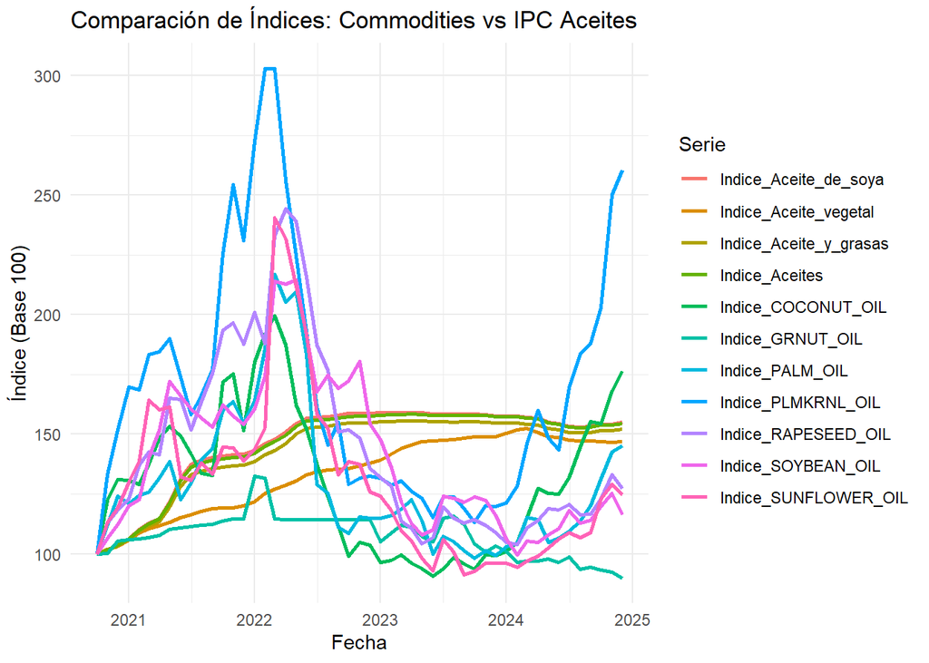

## 3.2 Matriz de Correlación

Matriz de Correlación entre Índices

|  | Indice_Aceite_y_grasas | Indice_Aceites | Indice_Aceite_de_soya | Indice_Aceite_vegetal | Indice_COCONUT_OIL | Indice_GRNUT_OIL | Indice_PALM_OIL | Indice_PLMKRNL_OIL | Indice_SOYBEAN_OIL | Indice_RAPESEED_OIL | Indice_SUNFLOWER_OIL |
| --- | --- | --- | --- | --- | --- | --- | --- | --- | --- | --- | --- |
| Indice_Aceite_y_grasas | 1.0000000 | 0.9993299 | 0.9984602 | 0.9159043 | -0.2477639 | -0.0334971 | -0.0967359 | -0.1286452 | 0.0162222 | -0.0613821 | -0.1899623 |
| Indice_Aceites | 0.9993299 | 1.0000000 | 0.9997660 | 0.9039416 | -0.2278485 | -0.0090165 | -0.0723192 | -0.1075984 | 0.0412699 | -0.0333038 | -0.1702430 |
| Indice_Aceite_de_soya | 0.9984602 | 0.9997660 | 1.0000000 | 0.8944792 | -0.2197473 | 0.0079417 | -0.0589618 | -0.0989348 | 0.0597493 | -0.0155664 | -0.1561428 |
| Indice_Aceite_vegetal | 0.9159043 | 0.9039416 | 0.8944792 | 1.0000000 | -0.3650194 | -0.3433524 | -0.3290371 | -0.2679824 | -0.3281517 | -0.3805715 | -0.4317676 |
| Indice_COCONUT_OIL | -0.2477639 | -0.2278485 | -0.2197473 | -0.3650194 | 1.0000000 | 0.1937487 | 0.8321143 | 0.9588334 | 0.5297472 | 0.7191477 | 0.6966605 |
| Indice_GRNUT_OIL | -0.0334971 | -0.0090165 | 0.0079417 | -0.3433524 | 0.1937487 | 1.0000000 | 0.4615553 | 0.2811837 | 0.6722497 | 0.6279386 | 0.4676189 |
| Indice_PALM_OIL | -0.0967359 | -0.0723192 | -0.0589618 | -0.3290371 | 0.8321143 | 0.4615553 | 1.0000000 | 0.8578285 | 0.7614019 | 0.8983323 | 0.8788335 |
| Indice_PLMKRNL_OIL | -0.1286452 | -0.1075984 | -0.0989348 | -0.2679824 | 0.9588334 | 0.2811837 | 0.8578285 | 1.0000000 | 0.5365390 | 0.7184985 | 0.6788484 |
| Indice_SOYBEAN_OIL | 0.0162222 | 0.0412699 | 0.0597493 | -0.3281517 | 0.5297472 | 0.6722497 | 0.7614019 | 0.5365390 | 1.0000000 | 0.9206632 | 0.8871733 |
| Indice_RAPESEED_OIL | -0.0613821 | -0.0333038 | -0.0155664 | -0.3805715 | 0.7191477 | 0.6279386 | 0.8983323 | 0.7184985 | 0.9206632 | 1.0000000 | 0.9059462 |
| Indice_SUNFLOWER_OIL | -0.1899623 | -0.1702430 | -0.1561428 | -0.4317676 | 0.6966605 | 0.4676189 | 0.8788335 | 0.6788484 | 0.8871733 | 0.9059462 | 1.0000000 |

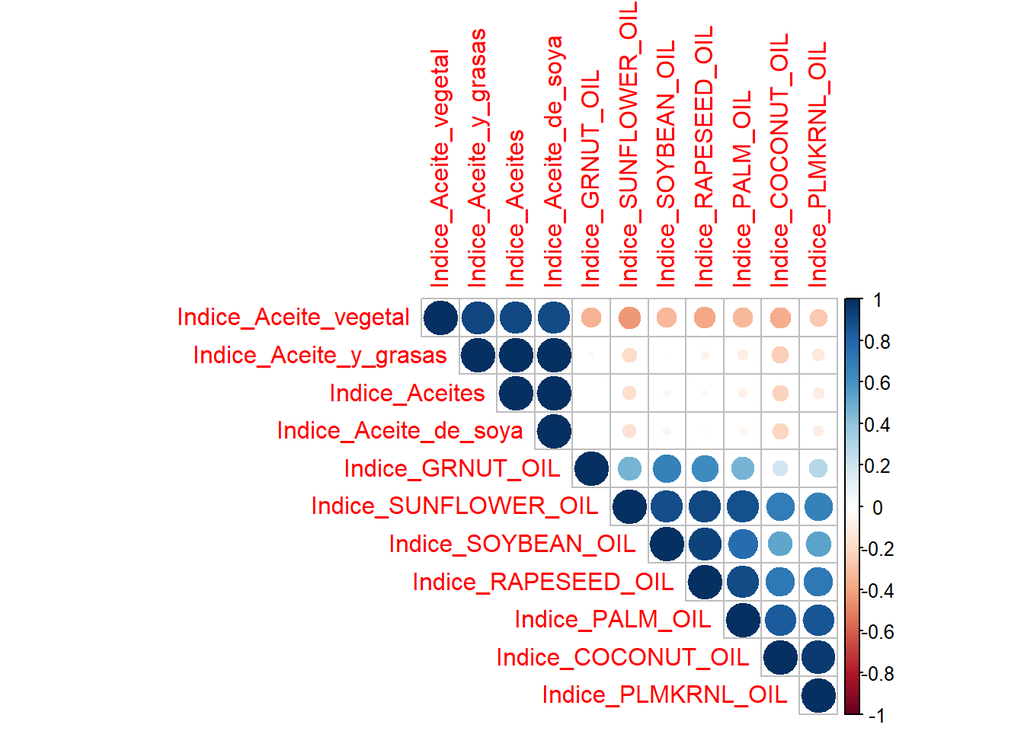

## 4. Análisis de Causalidad con Granger

este analisis mide los cambios entre ambas series:

Resultados del Análisis de Granger

| Res.Df | Df | F | Pr(>F) |
| --- | --- | --- | --- |
| 47 | NA | NA | NA |
| 48 | -1 | 22.49717 | 1.99e-05 |

## 5 Calculo de rezagos

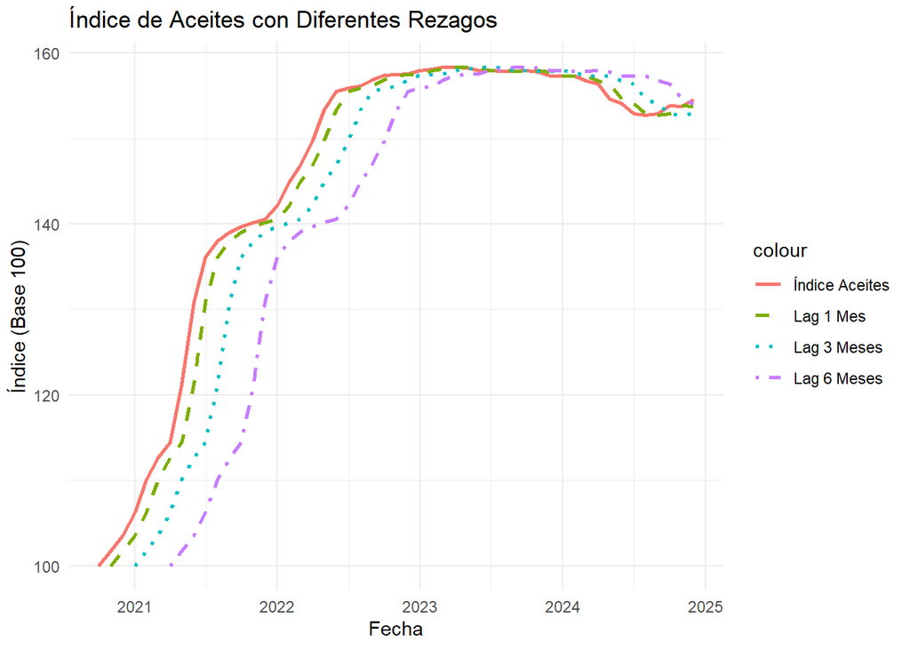

## 6 Correlación Movil

Extension de probabilidad para medir la relacion futura de la correlacion de ambos indices. este resultado revela que la relacion entre ellos no es estable ni uniforme con el tiempo, es decir que la correlación podria cambiar significativamente en choques externos.

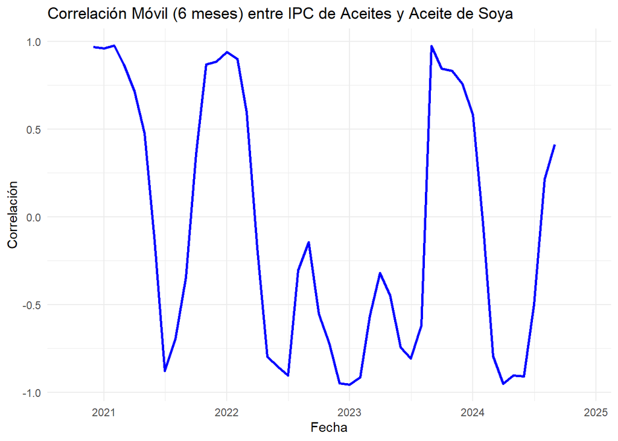

## Indice de los aceites y el promedio móvil

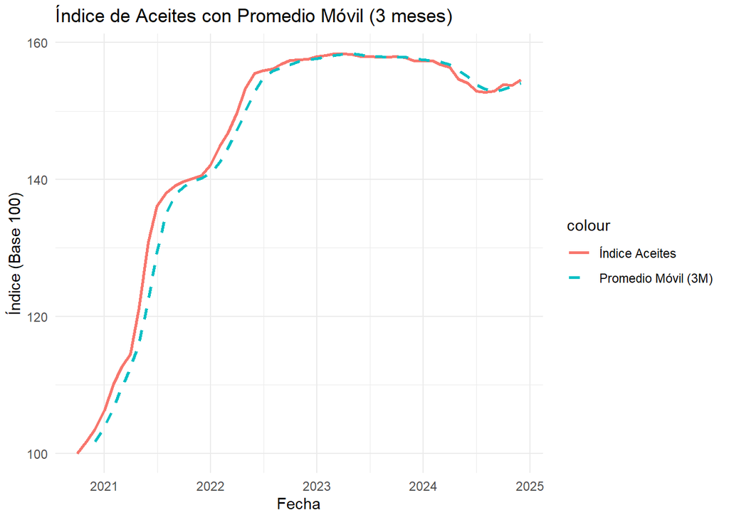